# Jupyter

### Merging DataFrames

Merging DataFrames combines DataFrames where the columns are the same.

```python
left = pd.DataFrame({'key': ['K0', 'K1', 'K2', 'K3'],
                     'A': ['A0', 'A1', 'A2', 'A3'],
                     'B': ['B0', 'B1', 'B2', 'B3']})
left
```

|  | key | A | B |
| --- | --- | --- | --- |
| 0 | K0 | A0 | B0 |
| 1 | K1 | A1 | B1 |
| 2 | K2 | A2 | B2 |
| 3 | K3 | A3 | B3 |

```python
right = pd.DataFrame({'key': ['K0', 'K1', 'K2', 'K3'],
                          'C': ['C0', 'C1', 'C2', 'C3'],
                          'D': ['D0', 'D1', 'D2', 'D3']})
right
```

|  | key | C | D |
| --- | --- | --- | --- |
| 0 | K0 | C0 | D0 |
| 1 | K1 | C1 | D1 |
| 2 | K2 | C2 | D2 |
| 3 | K3 | C3 | D3 |

If we just concatenate, then the column will show up multiple times.

```python
pd.concat([left, right], axis=1)
```

|  | key | A | B | key | C | D |
| --- | --- | --- | --- | --- | --- | --- |
| 0 | K0 | A0 | B0 | K0 | C0 | D0 |
| 1 | K1 | A1 | B1 | K1 | C1 | D1 |
| 2 | K2 | A2 | B2 | K2 | C2 | D2 |
| 3 | K3 | A3 | B3 | K3 | C3 | D3 |

If we merge, then the columns will merge into one column.

```python
pd.merge(left, right, on='key')
```

|  | key | A | B | C | D |
| --- | --- | --- | --- | --- | --- |
| 0 | K0 | A0 | B0 | C0 | D0 |
| 1 | K1 | A1 | B1 | C1 | D1 |
| 2 | K2 | A2 | B2 | C2 | D2 |
| 3 | K3 | A3 | B3 | C3 | D3 |

We can merge using multiple columns. Then only the rows where all the columns match are kept.

```python
left = pd.DataFrame({'key1': ['K0', 'K0', 'K1', 'K2'],
                     'key2': ['K0', 'K1', 'K0', 'K1'],
                        'A': ['A0', 'A1', 'A2', 'A3'],
                        'B': ['B0', 'B1', 'B2', 'B3']})
left
```

|  | key1 | key2 | A | B |
| --- | --- | --- | --- | --- |
| 0 | K0 | K0 | A0 | B0 |
| 1 | K0 | K1 | A1 | B1 |
| 2 | K1 | K0 | A2 | B2 |
| 3 | K2 | K1 | A3 | B3 |

```python
right = pd.DataFrame({'key1': ['K0', 'K1', 'K1', 'K2'],
                               'key2': ['K0', 'K0', 'K0', 'K0'],
                                  'C': ['C0', 'C1', 'C2', 'C3'],
                                  'D': ['D0', 'D1', 'D2', 'D3']})
right
```

|  | key1 | key2 | C | D |
| --- | --- | --- | --- | --- |
| 0 | K0 | K0 | C0 | D0 |
| 1 | K1 | K0 | C1 | D1 |
| 2 | K1 | K0 | C2 | D2 |
| 3 | K2 | K0 | C3 | D3 |

```python
pd.merge(left, right, on=['key1', 'key2'])
```

|  | key1 | key2 | A | B | C | D |
| --- | --- | --- | --- | --- | --- | --- |
| 0 | K0 | K0 | A0 | B0 | C0 | D0 |
| 1 | K1 | K0 | A2 | B2 | C1 | D1 |
| 2 | K1 | K0 | A2 | B2 | C2 | D2 |

### Joining DataFrames

Join is like merge except that the keys we want to merge on are the indices.

```python
left = pd.DataFrame({'A': ['A0', 'A1', 'A2'],
                     'B': ['B0', 'B1', 'B2']},
                      index=['K0', 'K1', 'K2'])
left
```

|  | A | B |
| --- | --- | --- |
| K0 | A0 | B0 |
| K1 | A1 | B1 |
| K2 | A2 | B2 |

```python
right = pd.DataFrame({'C': ['C0', 'C2', 'C3'],
                    'D': ['D0', 'D2', 'D3']},
                      index=['K0', 'K2', 'K3'])
right
```

|  | C | D |
| --- | --- | --- |
| K0 | C0 | D0 |
| K2 | C2 | D2 |
| K3 | C3 | D3 |

```python
left.join(right)
```

|  | A | B | C | D |
| --- | --- | --- | --- | --- |
| K0 | A0 | B0 | C0 | D0 |
| K1 | A1 | B1 | NaN | NaN |
| K2 | A2 | B2 | C2 | D2 |

### Finding Unique Values

```python
df = pd.DataFrame({'col1': [1,2,3,4],
                   'col2': [444,555,666,444],
                   'col3': ['abc', 'def', 'ghi', 'xyz']})
df
```

|  | col1 | col2 | col3 |
| --- | --- | --- | --- |
| 0 | 1 | 444 | abc |
| 1 | 2 | 555 | def |
| 2 | 3 | 666 | ghi |
| 3 | 4 | 444 | xyz |

#### `unique()`

```python
df['col2'].unique()
```

```
array([444, 555, 666], dtype=int64)
```

#### `nunique()`

```python
df['col2'].nunique()
```

```
3
```

#### `value_counts()`

```python
df['col2'].value_counts()
```

```
444    2
555    1
666    1
Name: col2, dtype: int64
```

### Removing Columns

```python
df.drop('col1', axis=1)
```

|  | col2 | col3 |
| --- | --- | --- |
| 0 | 444 | abc |
| 1 | 555 | def |
| 2 | 666 | ghi |
| 3 | 444 | xyz |

### Sorting

```python
df.sort_values('col2')
```

|  | col1 | col2 | col3 |
| --- | --- | --- | --- |
| 0 | 1 | 444 | abc |
| 3 | 4 | 444 | xyz |
| 1 | 2 | 555 | def |
| 2 | 3 | 666 | ghi |

### Pivot Table

A pivot table is a multi-index DataFrame. (?)

```python
df = pd.DataFrame({'A':['foo', 'foo', 'foo', 'bar', 'bar', 'bar'],
                   'B':['one', 'one', 'two', 'two', 'one', 'one'],
                   'C':['x', 'y', 'x', 'y', 'x', 'y'],
                   'D':[1, 3, 2, 5, 4, 1]})
df
```

|  | A | B | C | D |
| --- | --- | --- | --- | --- |
| 0 | foo | one | x | 1 |
| 1 | foo | one | y | 3 |
| 2 | foo | two | x | 2 |
| 3 | bar | two | y | 5 |
| 4 | bar | one | x | 4 |
| 5 | bar | one | y | 1 |

```python
df.pivot_table(values='D', index=['A','B'], columns=['C'])
```

| A | C B | x | y |
| --- | --- | --- | --- |
| bar | one | 4.0 | 1.0 |
|  | two | NaN | 5.0 |
| foo | one | 1.0 | 3.0 |
|  | two | 2.0 | NaN |

## Tips

For answering questions such as "How many ...", using `sum()` on a Series of boolean values will return a number indicating the number of `True` entries.

# Matplotlib

```python
import matplotlib.pyplot as plt
```

`figure` is like a blank canvas.

The arguments to `add_axes()` are:

- move _% from the left
- move _% from the bottom
- width (_% of figure width)
- height (_% of figure height)

```python
x = np.linspace(0,11,10)
y = x**2
```

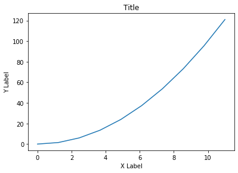

```python
fig = plt.figure()
axes = fig.add_axes([0.1, 0.1, 0.8, 0.8])
axes.plot(x,y)
axes.set_xlabel('X Label')
axes.set_ylabel('Y Label')
axes.set_title('Title')
plt.show()
```

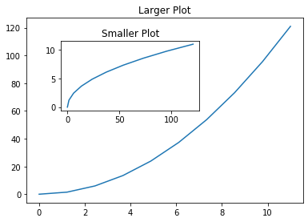

```python
fig = plt.figure()
axes1 = fig.add_axes([0.1, 0.1, 0.8, 0.8])
axes2 = fig.add_axes([0.2, 0.5, 0.4, 0.3])

axes1.plot(x,y)
axes1.set_title('Larger Plot')

axes2.plot(y,x)
axes2.set_title('Smaller Plot')

plt.show()
```

## Subplots

Subplots automatically does the `add_axes()` stuff behind the scenes.

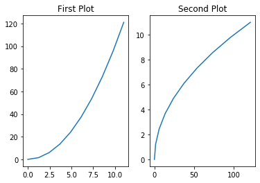

```python
fig, axes = plt.subplots(nrows=1, ncols=2)

axes[0].plot(x,y)
axes[0].set_title('First Plot')

axes[1].plot(y,x)
axes[1].set_title('Second Plot')

plt.show()
```

## Figure Size and DPI

`figsize` is a keyword argument that takes in a tuple specifying width and height in inches.

`dpi` specifies dots per inch

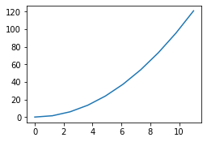

```python
fig = plt.figure(figsize=(3,2))
ax = fig.add_axes([0,0,1,1])
ax.plot(x,y)
plt.show()
```

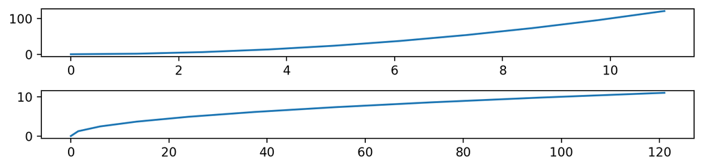

```python
fig, axes = plt.subplots(nrows=2, ncols=1, figsize=(8,2), dpi=200)
axes[0].plot(x,y)
axes[1].plot(y,x)
plt.tight_layout()
plt.show()
```

## Legends

The legend gets the text from the keyword argument `label`.

The legend takes in an optional keyword argument `loc` which can take in a tuple specifying *% left and* % bottom.

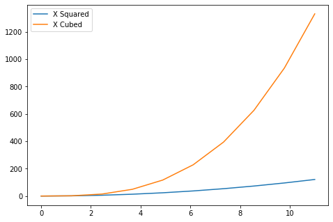

```python
fig = plt.figure()
ax = fig.add_axes([0,0,1,1])

ax.plot(x, x**2, label='X Squared')
ax.plot(x, x**3, label='X Cubed')

ax.legend()
# ax.legend(loc=(0.1,0.1))
plt.show()
```

## Colors

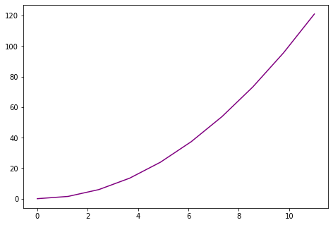

```python
fig = plt.figure()
ax = fig.add_axes([0,0,1,1])
ax.plot(x,y,color='purple')
# ax.plot(x,y,color='#FF8928')
plt.show()
```